# Human Activity Recognition using a Random Forest Model

Kelvin DeCosta

## Introduction

Using devices such as Jawbone Up, Nike FuelBand, and Fitbit it is now possible to collect a large amount of data about personal activity relatively inexpensively. These type of devices are part of the quantified self movement – a group of enthusiasts who take measurements about themselves regularly to improve their health, to find patterns in their behavior, or because they are tech geeks. One thing that people regularly do is quantify how much of a particular activity they do, but they rarely quantify how well they do it.

In this project, we will use data from accelerometers on the belt, forearm, arm, and dumbell of 6 participants to predict the manner in which they did the exercise.

### Setup

```r
# Load libraries
library(caret)
library(corrplot)
library(randomForest)
library(rpart)
library(rpart.plot)
```

## Data Preprocessing

### Downloading

The data used in this project came from [this source](http://groupware.les.inf.puc-rio.br/har).

```r
train_url <-"https://d396qusza40orc.cloudfront.net/predmachlearn/pml-training.csv"
test_url <- "https://d396qusza40orc.cloudfront.net/predmachlearn/pml-testing.csv"
train_path <- "./data/pml-training.csv"
test_path  <- "./data/pml-testing.csv"

if (!file.exists("./data")) {
  dir.create("./data")
}

if (!file.exists(train_path)) {
  download.file(train_url, destfile=train_path, method="curl")
}

if (!file.exists(test_path)) {
  download.file(test_url, destfile=test_path, method="curl")
}
```

### Reading

Let us read the two files.

```r
train_raw <- read.csv("./data/pml-training.csv")
test_raw <- read.csv("./data/pml-testing.csv")
dim(train_raw)
```

```
## [1] 19622   160
```

```r
dim(test_raw)
```

```
## [1]  20 160
```

This dataset contains 19,622 and 20 observations of 160 features that are split into a train and test set. Our goal is to predict `classe`.

### Cleaning

First, we discard all features that contain `NA`, i.e., missing values.

```r
train_raw <- train_raw[, colSums(is.na(train_raw)) == 0]
test_raw <- test_raw[, colSums(is.na(test_raw)) == 0]
```

Next, we discard features that are unrelated to the accelerometers.

```r
classe <- train_raw$classe

discard_columns <- grepl("^X|timestamp|window", names(train_raw))
train_raw <- train_raw[, !discard_columns]
train_cleaned <- train_raw[, sapply(train_raw, is.numeric)]

train_cleaned$classe <- classe
discard_columns <- grepl("^X|timestamp|window", names(test_raw))
test_raw <- test_raw[, !discard_columns]
test_cleaned <- test_raw[, sapply(test_raw, is.numeric)]
```

This cleaned dataset contains 19622 and 20 observations of just 53 features.

### Splitting

Since we will perform predictions on the `test_cleaned` data, we require a different dataset for cross-validation. We will split the large `train_cleaned` data into training (75%) and validation (25%) sets.

```r
set.seed(42)
split_index <- createDataPartition(train_cleaned$classe, p=0.75, list=FALSE)
train_data <- train_cleaned[split_index, ]
test_data <- train_cleaned[-split_index, ]
```

## Model

We design a predictive model for human activity recognition using the **Random Forest** algorithm.

A few justifications for this choice of model are:

- that it can select important features automatically, and
- that it is robust to correlated features and outliers.

We will use *5-fold* cross validation when applying the algorithm.

```r
control_rand_forest <- trainControl(method="cv", 5)
rand_forest_model <- train(classe ~ ., data=train_data, method="rf", trControl=control_rand_forest, ntree=128)
rand_forest_model
```

```
## Random Forest
##
## 14718 samples
##    52 predictor
##     5 classes: 'A', 'B', 'C', 'D', 'E'
##
## No pre-processing
## Resampling: Cross-Validated (5 fold)
## Summary of sample sizes: 11774, 11774, 11775, 11774, 11775
## Resampling results across tuning parameters:
##
##   mtry  Accuracy   Kappa
##    2    0.9916429  0.9894274
##   27    0.9913030  0.9889978
##   52    0.9860033  0.9822911
##
## Accuracy was used to select the optimal model using the largest value.
## The final value used for the model was mtry = 2.
```

We can estimate the performance of this model by preforming some predictions on the validation set.

```r
predictions <- predict(rand_forest_model, test_data)
conf_matrix <- confusionMatrix(predictions, as.factor(test_data$classe))
conf_matrix
```

```
## Confusion Matrix and Statistics
##
##           Reference
## Prediction    A    B    C    D    E
##          A 1395    4    0    0    0
##          B    0  941    7    0    0
##          C    0    4  847   19    0
##          D    0    0    1  783    0
##          E    0    0    0    2  901
##
## Overall Statistics
##
##                Accuracy : 0.9925
##                  95% CI : (0.9896, 0.9947)
##     No Information Rate : 0.2845
##     P-Value [Acc > NIR] : < 2.2e-16
##
##                   Kappa : 0.9905
##
##  Mcnemar's Test P-Value : NA
##
## Statistics by Class:
##
##                      Class: A Class: B Class: C Class: D Class: E
## Sensitivity            1.0000   0.9916   0.9906   0.9739   1.0000
## Specificity            0.9989   0.9982   0.9943   0.9998   0.9995
## Pos Pred Value         0.9971   0.9926   0.9736   0.9987   0.9978
## Neg Pred Value         1.0000   0.9980   0.9980   0.9949   1.0000
## Prevalence             0.2845   0.1935   0.1743   0.1639   0.1837
## Detection Rate         0.2845   0.1919   0.1727   0.1597   0.1837
## Detection Prevalence   0.2853   0.1933   0.1774   0.1599   0.1841
## Balanced Accuracy      0.9994   0.9949   0.9925   0.9868   0.9998
```

```r
accuracy <- postResample(predictions, as.factor(test_data$classe))
accuracy
```

```
##  Accuracy     Kappa
## 0.9924551 0.9904552
```

```r
out_of_sample_err <- 1 - as.numeric(conf_matrix$overall[1])
out_of_sample_err
```

```
## [1] 0.007544861
```

## Testing

Finally, we perform predictions on the original test data.

```r
result <- predict(rand_forest_model, test_cleaned[, -length(names(test_cleaned))]) # Discard `problem_id`.
result
```

```
##  [1] B A B A A E D B A A B C B A E E A B B B
## Levels: A B C D E
```

## Conclusion

We designed a Random Forest model that achieved an accuracy of 99.2% and had an out of sample error rate of 0.7%.

## Appendix

### 1. Correlation Matrix of Features

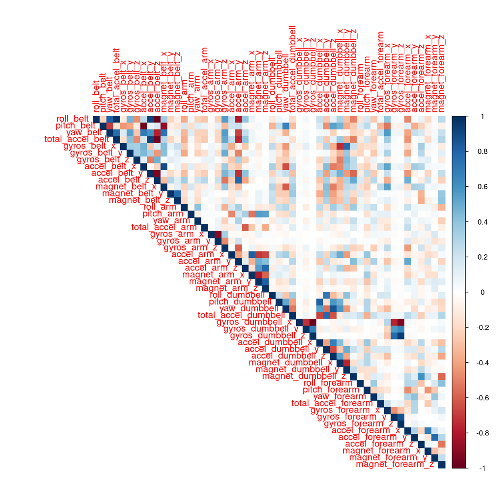

```r
corrPlot <- cor(train_data[, -length(names(train_data))])
corrplot(corrPlot, method="color", type = "upper")
```

### 2. Decision Tree

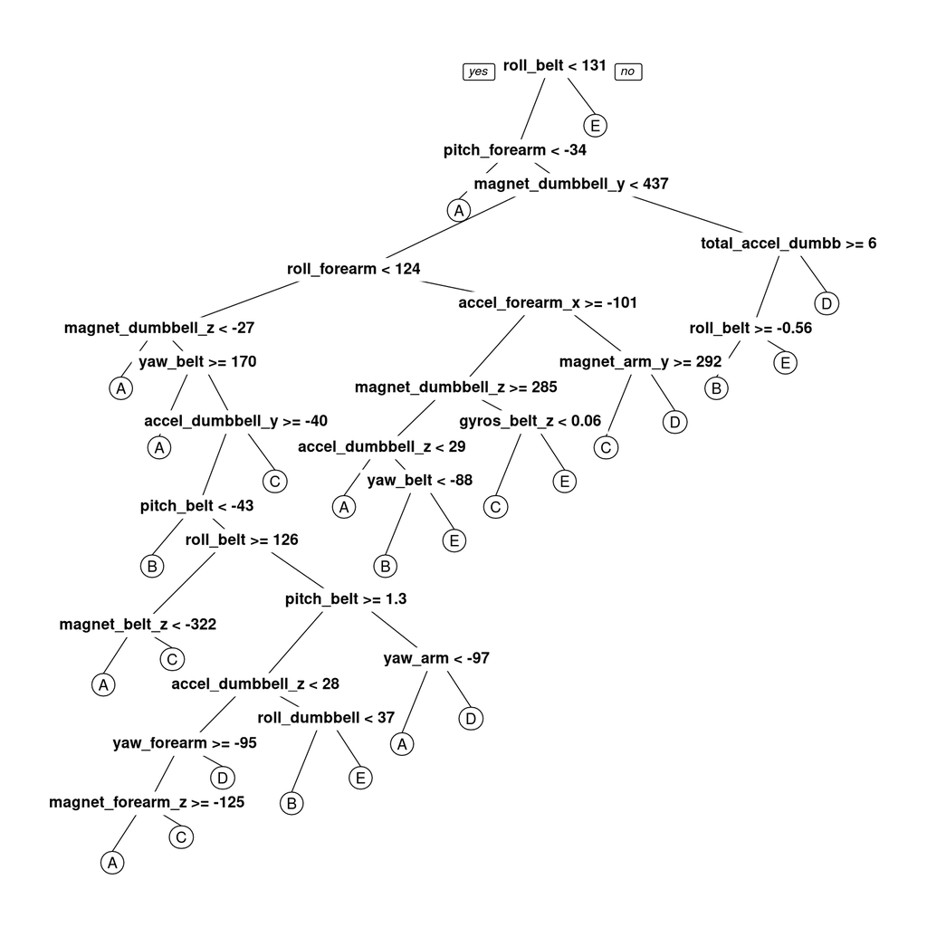

```r
treeModel <- rpart(classe ~ ., data=train_data, method="class")
prp(treeModel)
```